# 24133064_NguyenThiKieuTrang_EXERCISES_MODEL

2026-06-13

BÀI TẬP MÔ HÌNH HỒI QUY TRONG R

Câu 1:

Sử dụng Linenear Regression để thực hiện việc dự đoán FEV dựa trên các thuộc tính age/ age và ht

# 1. Đọc dữ liệu và gán cho biến data

```r
data <- read.csv("children_lung.csv")
```

# 2. Xem thông tin data: head(), số dòng, số cột, summary

```r
head(data)
```

```
##   age   FEV   ht sex smoke
## 1   9 1.708 57.0   0     0
## 2   8 1.724 67.5   0     0
## 3   7 1.720 54.5   0     0
## 4   9 1.558 53.0   1     0
## 5   9 1.895 57.0   1     0
## 6   8 2.336 61.0   0     0
```

```r
nrow(data)
```

```
## [1] 654
```

```r
ncol(data)
```

```
## [1] 5
```

```r
summary(data)
```

```
##       age             FEV               ht             sex
##  Min.   :1.458   Min.   : 0.791   Min.   :46.00   Min.   :0.0000
##  1st Qu.:3.049   1st Qu.: 2.041   1st Qu.:53.50   1st Qu.:0.0000
##  Median :4.330   Median :59.000   Median :57.00   Median :0.0000
##  Mean   :5.205   Mean   :35.210   Mean   :56.92   Mean   :0.4984
##  3rd Qu.:8.000   3rd Qu.:65.000   3rd Qu.:60.00   3rd Qu.:1.0000
##  Max.   :9.000   Max.   :74.000   Max.   :69.00   Max.   :1.0000
##                                   NAs    :345     NAs    :345
##      smoke
##  Min.   :0.000000
##  1st Qu.:0.000000
##  Median :0.000000
##  Mean   :0.003236
##  3rd Qu.:0.000000
##  Max.   :1.000000
##  NAs    :345
```

# 3. Tiền xử lý ( nếu cần)

## Kiểm tra và xử lý giá trị thiếu

```r
sum(is.na(data))
```

```
## [1] 1035
```

```r
colSums(is.na(data))
```

```
##   age   FEV    ht   sex smoke
##     0     0   345   345   345
```

```r
data$age[is.na(data$ht)] <- median(data$ht, na.rm=TRUE)
data$age[is.na(data$sex)] <- median(data$sex, na.rm=TRUE)
data$age[is.na(data$smoke)] <- median(data$smoke, na.rm=TRUE)

sum(is.na(data))
```

```
## [1] 1035
```

## Kiểm tra và xử lý giá trị trùng

```r
sum(duplicated(data))
```

```
## [1] 310
```

```r
data <- data[!duplicated(data),]
sum(duplicated(data))
```

```
## [1] 0
```

# 4. Vẽ biểu đồ quan sát mối liên hệ giữa FEV và age

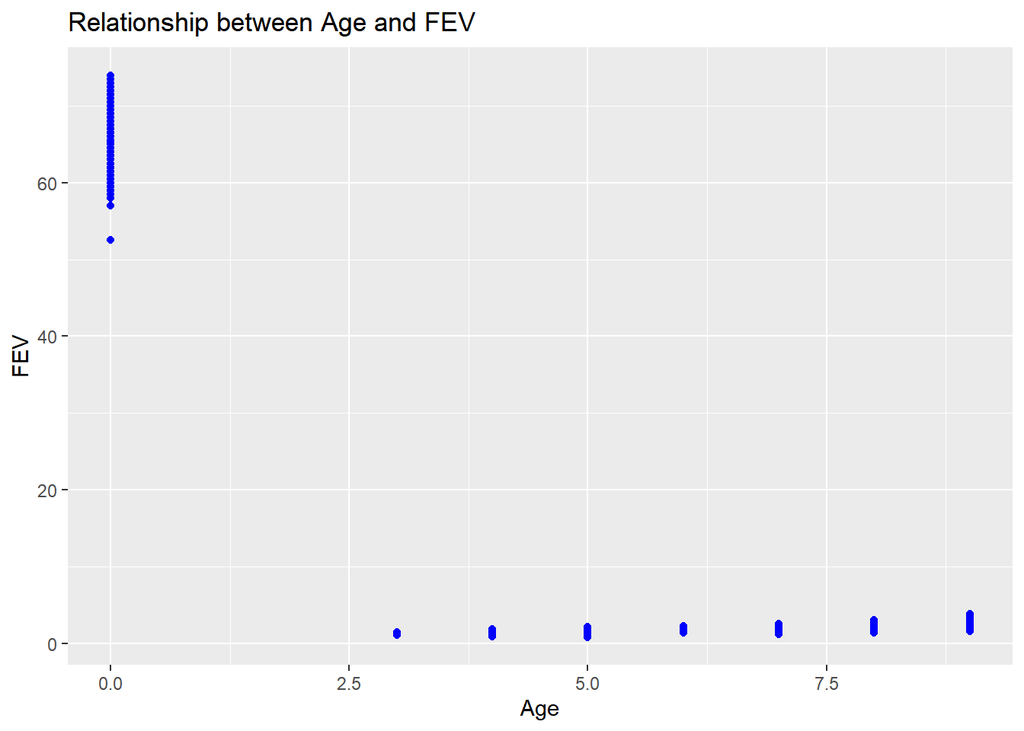

```r
ggplot(data=data, aes(x=age,y=FEV))+
  geom_point(color="blue", shape=19)+
  labs(
    title="Relationship between Age and FEV",
    x="Age",
    x="FEV"
  )
```

Nhận xét

Vấn đề vi phạm giả định hồi quy

- Vi phạm giả định về đồng phương sai (Heteroscedasticity): Dấu hiệu trên biểu đồ: Độ phân tán (độ dài) của các cột dữ liệu thay đổi rõ rệt theo xu hướng tăng dần của tuổi. Ở mốc tuổi nhỏ (3, 4 tuổi), các điểm dữ liệu tập trung rất sát nhau (biến động nhỏ). Tuy nhiên, càng về các mốc tuổi lớn (8, 9 tuổi), các điểm dữ liệu càng loe rộng ra tạo thành hình cái phễu (biến động cực kỳ lớn).
- Xu hướng phi tuyến tính nhẹ ở hai đầu dữ liệu: Dấu hiệu trên biểu đồ: Tốc độ tăng trưởng của FEV không hoàn toàn đều đặn theo một đường thẳng tuyệt đối. Nếu nhìn kỹ từ mốc 3 tuổi đến 9 tuổi, đường đi của các điểm dữ liệu có xu hướng hơi cong nhẹ hướng lên (độ dốc ở các mốc tuổi lớn cao hơn mốc tuổi nhỏ).

# 5. Chia data thành 2 bộ dữ liệu data_FEV_less_10 và data_FEV_more_10

```r
data_FEV_less_10 <- subset(data, FEV<10)
data_FEV_more_10 <- subset(data, FEV>=10)

dim(data_FEV_less_10)
```

```
## [1] 308   5
```

```r
dim(data_FEV_more_10)
```

```
## [1] 36  5
```

# 6. Với data_FEV_more_10

## a. Thực hiện Simple Linear Regression để dự đoán FEV từ age. Xây dựng model. Đánh giá model

```r
model1 <- lm(FEV~age,data=data_FEV_more_10)
summary(model1)
```

```
##
## Call:
## lm(formula = FEV ~ age, data = data_FEV_more_10)
##
## Residuals:
##      Min       1Q   Median       3Q      Max
## -12.8583  -3.9833   0.0917   4.2667   8.6417
##
## Coefficients: (1 not defined because of singularities)
##             Estimate Std. Error t value Pr(>|t|)
## (Intercept)  65.3583     0.8894   73.48   <2e-16 ***
## age               NA         NA      NA       NA
## ---
## Signif. codes:  0 '***' 0.001 '**' 0.01 '*' 0.05 '.' 0.1 ' ' 1
##
## Residual standard error: 5.337 on 35 degrees of freedom
```

## b. Cho age lần lượt là:[2,3,4,5]. Hãy cho biết FEV lần lượt là bao nhiêu?

```r
new_data <- data.frame(
  age=c(2,3,4,5)
  )
predict(model1, new_data)
```

```
##        1        2        3        4
## 65.35833 65.35833 65.35833 65.35833
## attr(,"non-estim")
## 1 2 3 4
## 1 2 3 4
```

## c.Trực quan hóa kết quả

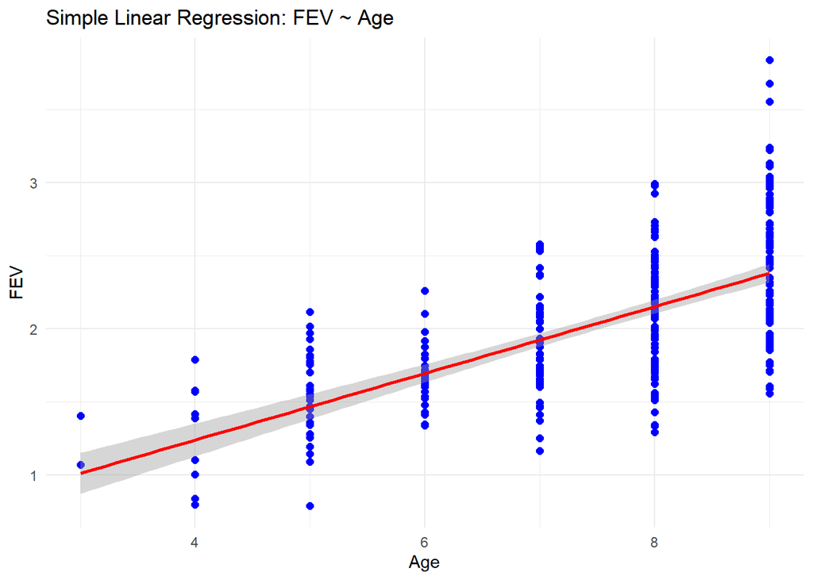

```r
ggplot(data_FEV_less_10,aes(x = age, y = FEV)) +
  geom_point(color = "blue", size = 2) +
  geom_smooth(method = "lm",
              se = TRUE,
              color = "red") +
  labs(title = "Simple Linear Regression: FEV ~ Age",
       x = "Age",
       y = "FEV") +
  theme_minimal()
```

# 7. Với data_FEV_less_10

## a. Thực hiện Multiple Linear Regression để dự đoán FEV từ age và ht

```r
model2 <- lm(FEV~age+ht, data=data_FEV_less_10)
summary(model2)
```

```
##
## Call:
## lm(formula = FEV ~ age + ht, data = data_FEV_less_10)
##
## Residuals:
##     Min      1Q  Median      3Q     Max
## -1.2799 -0.1857 -0.0023  0.1880  1.0386
##
## Coefficients:
##              Estimate Std. Error t value Pr(>|t|)
## (Intercept) -3.270098   0.251511 -13.002   <2e-16 ***
## age          0.014946   0.018074   0.827    0.409
## ht           0.091177   0.005979  15.248   <2e-16 ***
## ---
## Signif. codes:  0 '***' 0.001 '**' 0.01 '*' 0.05 '.' 0.1 ' ' 1
##
## Residual standard error: 0.2931 on 305 degrees of freedom
## Multiple R-squared:  0.6735, Adjusted R-squared:  0.6713
## F-statistic: 314.6 on 2 and 305 DF,  p-value: < 2.2e-16
```

## b. Cho age và ht lần lượt là: age=[5,6,7,8,9], ht=[49.5,55,57,60,62]. Hãy cho biết FEV lần lượt là bao nhiêu

```r
new_data2 <- data.frame(
  age=c(5,6,7,8,9),
  ht=c(49.5,55,57,60,62)
)
predict(model2, new_data2)
```

```
##        1        2        3        4        5
## 1.317875 1.834293 2.031592 2.320068 2.517367
```

## c. Trực quan hóa kết quả

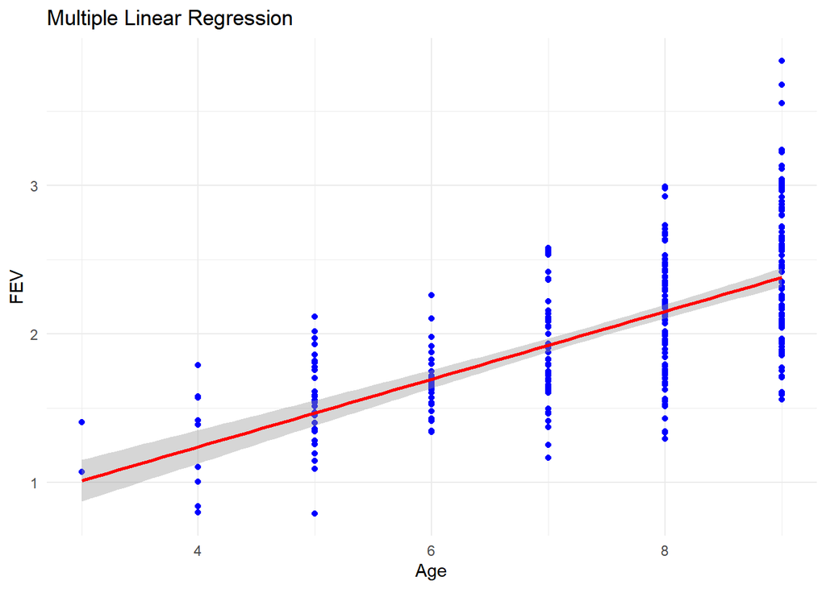

```r
ggplot(data_FEV_less_10,
       aes(x = age, y = FEV)) +
  geom_point(color = "blue") +
  geom_smooth(method = "lm",
              color = "red",
              se = TRUE) +
  theme_minimal() +
  labs(title = "Multiple Linear Regression",
       x = "Age",
       y = "FEV")
```

Nhận xét

- Biểu đồ cho thấy FEV có xu hướng tăng theo tuổi (Age). Đường hồi quy màu đỏ có độ dốc dương, chứng tỏ tồn tại mối quan hệ cùng chiều giữa Age và FEV. Phần lớn các điểm dữ liệu phân bố xung quanh đường hồi quy, cho thấy mô hình có khả năng mô tả tương đối tốt xu hướng của dữ liệu.
- Đồng thời, độ phân tán của FEV ở các nhóm tuổi lớn hơn có xu hướng tăng, cho thấy ngoài Age còn có những yếu tố khác ảnh hưởng đến FEV. Trong mô hình hồi quy tuyến tính bội, biến chiều cao (ht) được bổ sung nhằm cải thiện khả năng dự đoán FEV.

Câu 2

# 1. Đọc dữ liệu và gán cho biến data

```r
data2 <- read.csv("mushrooms.csv", stringsAsFactors = TRUE)
```

# 2. Xem thông tin data : head(), số dòng, số cột, summary…

```r
head(data2)
```

```
##   class cap.shape cap.surface cap.color bruises odor gill.attachment
## 1     p         x           s         n       t    p               f
## 2     e         x           s         y       t    a               f
## 3     e         b           s         w       t    l               f
## 4     p         x           y         w       t    p               f
## 5     e         x           s         g       f    n               f
## 6     e         x           y         y       t    a               f
##   gill.spacing gill.size gill.color stalk.shape stalk.root
## 1            c         n          k           e          e
## 2            c         b          k           e          c
## 3            c         b          n           e          c
## 4            c         n          n           e          e
## 5            w         b          k           t          e
## 6            c         b          n           e          c
##   stalk.surface.above.ring stalk.surface.below.ring stalk.color.above.ring
```

[output cut: 20 more lines]

```r
nrow(data2)
```

```
## [1] 8124
```

```r
ncol(data2)
```

```
## [1] 23
```

```r
summary(data2)
```

```
##  class    cap.shape cap.surface   cap.color    bruises       odor
##  e:4208   b: 452    f:2320      n      :2284   f:4748   n      :3528
##  p:3916   c:   4    g:   4      g      :1840   t:3376   f      :2160
##           f:3152    s:2556      e      :1500            s      : 576
##           k: 828    y:3244      y      :1072            y      : 576
##           s:  32                w      :1040            a      : 400
##           x:3656                b      : 168            l      : 400
##                                 (Other): 220            (Other): 484
##  gill.attachment gill.spacing gill.size   gill.color   stalk.shape stalk.root
##  a: 210          c:6812       b:5612    b      :1728   e:3516      ?:2480
##  f:7914          w:1312       n:2512    p      :1492   t:4608      b:3776
##                                         w      :1202               c: 556
##                                         n      :1048               e:1120
##                                         g      : 752               r: 192
##                                         h      : 732
##                                         (Other):1170
##  stalk.surface.above.ring stalk.surface.below.ring stalk.color.above.ring
##  f: 552                   f: 600                   w      :4464
##  k:2372                   k:2304                   p      :1872
##  s:5176                   s:4936                   g      : 576
##  y:  24                   y: 284                   n      : 448
##                                                    b      : 432
##                                                    o      : 192
##                                                    (Other): 140
##  stalk.color.below.ring veil.type veil.color ring.number ring.type
##  w      :4384           p:8124    n:  96     n:  36      e:2776
##  p      :1872                     o:  96     o:7488      f:  48
##  g      : 576                     w:7924     t: 600      l:1296
##  n      : 512                     y:   8                 n:  36
##  b      : 432                                            p:3968
##  o      : 192
##  (Other): 156
##  spore.print.color population habitat
##  w      :2388      a: 384     d:3148
##  n      :1968      c: 340     g:2148
##  k      :1872      n: 400     l: 832
##  h      :1632      s:1248     m: 292
##  r      :  72      v:4040     p:1144
##  b      :  48      y:1712     u: 368
##  (Other): 144                 w: 192
```

# 3. Tiền xử lý dữ liệu

```r
sum(is.na(data2))
```

```
## [1] 0
```

```r
sum(duplicated(data2))
```

```
## [1] 0
```

# 4.Tạo train và test từ dữ liệu data

```r
data2$veil.type <- NULL
data2[] <- lapply(data2, as.factor)

set.seed(123)

index <- createDataPartition(
  data2$class,
  p = 0.8,
  list = FALSE
)

train_data <- data2[index, ]
test_data  <- data2[-index, ]

dim(train_data)
```

```
## [1] 6500   22
```

```r
dim(test_data)
```

```
## [1] 1624   22
```

# 5. Xây dựng model với train

```r
# Logistic Regression

model_logit <- glm(
  class ~ .,
  data = train_data,
  family = binomial
)
# Decision Tree

model_tree <- rpart(
  class ~ .,
  data = train_data,
  method = "class"
)
```

# 6. In summary của model

```r
summary(model_logit)
```

```
##
## Call:
## glm(formula = class ~ ., family = binomial, data = train_data)
##
## Coefficients: (10 not defined because of singularities)
##                             Estimate Std. Error z value Pr(>|z|)
## (Intercept)               -2.657e+01  3.447e+05       0        1
## cap.shapec                 2.985e-08  2.120e+05       0        1
## cap.shapef                 2.845e-09  2.645e+04       0        1
## cap.shapek                -7.138e-09  2.888e+04       0        1
## cap.shapes                 1.436e-09  9.103e+04       0        1
## cap.shapex                 2.048e-09  2.536e+04       0        1
## cap.surfaceg              -2.535e-08  2.729e+05       0        1
## cap.surfaces              -2.761e-09  1.506e+04       0        1
## cap.surfacey               2.121e-09  1.253e+04       0        1
## cap.colorc                -8.164e-07  8.529e+04       0        1
## cap.colore                -8.260e-07  4.073e+04       0        1
## cap.colorg                -8.715e-07  3.915e+04       0        1
## cap.colorn                -8.360e-07  3.981e+04       0        1
## cap.colorp                -6.249e-07  4.923e+04       0        1
## cap.colorr                -9.036e-07  1.428e+05       0        1
## cap.coloru                -9.033e-07  1.362e+05       0        1
## cap.colorw                -9.037e-07  3.946e+04       0        1
## cap.colory                -8.730e-07  4.186e+04       0        1
## bruisest                   2.657e+01  1.254e+05       0        1
## odorc                      2.657e+01  1.532e+05       0        1
## odorf                     -2.657e+01  3.780e+05       0        1
## odorl                      8.708e-10  2.834e+04       0        1
## odorm                      1.328e+02  5.846e+05       0        1
## odorn                     -7.970e+01  3.619e+05       0        1
## odorp                     -5.313e+01  4.439e+05       0        1
## odors                     -2.657e+01  3.787e+05       0        1
## odory                     -2.657e+01  3.787e+05       0        1
## gill.attachmentf           4.685e-06  1.347e+05       0        1
## gill.spacingw             -4.809e-06  5.783e+04       0        1
## gill.sizen                -7.970e+01  3.353e+05       0        1
## gill.colore               -2.657e+01  2.346e+05       0        1
## gill.colorg               -2.657e+01  2.322e+05       0        1
## gill.colorh               -2.657e+01  2.318e+05       0        1
## gill.colork               -2.657e+01  2.325e+05       0        1
```

[output cut: 55 more lines]

```
## populationy               -1.179e-08  4.019e+04       0        1
## habitatg                   8.739e-09  2.353e+04       0        1
## habitatl                   3.862e-09  2.227e+04       0        1
## habitatm                   9.787e-09  4.066e+04       0        1
## habitatp                   7.675e-09  1.749e+04       0        1
## habitatu                  -3.360e-06  4.183e+04       0        1
## habitatw                          NA         NA      NA       NA
##
## (Dispersion parameter for binomial family taken to be 1)
##
##     Null deviance: 9.0025e+03  on 6499  degrees of freedom
## Residual deviance: 3.7710e-08  on 6414  degrees of freedom
## AIC: 172
##
## Number of Fisher Scoring iterations: 25
```

```r
summary(model_tree)
```

```
## Call:
## rpart(formula = class ~ ., data = train_data, method = "class")
##   n= 6500
##
##           CP nsplit  rel error     xerror        xstd
## 1 0.96744335      0 1.00000000 1.00000000 0.012858333
## 2 0.01851261      1 0.03255665 0.03255665 0.003198196
## 3 0.01000000      2 0.01404405 0.01404405 0.002110042
##
## Variable importance
##                     odor        spore.print.color               gill.color
##                       25                       19                       15
## stalk.surface.below.ring stalk.surface.above.ring                ring.type
##                       14                       14                       13
##
## Node number 1: 6500 observations,    complexity param=0.9674433
##   predicted class=e  expected loss=0.482  P(node) =1
##     class counts:  3367  3133
##    probabilities: 0.518 0.482
##   left son=2 (3469 obs) right son=3 (3031 obs)
##   Primary splits:
##       odor                     splits as  LRRLRLRRR,    improve=3047.786, (0 missing)
##       spore.print.color        splits as  LRLLLRLRL,    improve=1792.459, (0 missing)
##       gill.color               splits as  RLRRLLLLRLLL, improve=1249.823, (0 missing)
##       stalk.surface.above.ring splits as  LRLL,         improve=1158.002, (0 missing)
##       stalk.surface.below.ring splits as  LRLL,         improve=1109.059, (0 missing)
##   Surrogate splits:
##       spore.print.color        splits as  LRLLLLLRL,    agree=0.864, adj=0.709, (0 split)
##       gill.color               splits as  RLRRLLLLLLLL, agree=0.814, adj=0.601, (0 split)
##       stalk.surface.below.ring splits as  LRLL,         agree=0.787, adj=0.543, (0 split)
##       stalk.surface.above.ring splits as  LRLL,         agree=0.786, adj=0.540, (0 split)
##       ring.type                splits as  RLRRL,        agree=0.778, adj=0.524, (0 split)
##
## Node number 2: 3469 observations,    complexity param=0.01851261
##   predicted class=e  expected loss=0.02940329  P(node) =0.5336923
##     class counts:  3367   102
##    probabilities: 0.971 0.029
##   left son=4 (3411 obs) right son=5 (58 obs)
##   Primary splits:
##       spore.print.color        splits as  LLLLLRLLL,    improve=111.13690, (0 missing)
##       stalk.color.below.ring   splits as  --LLLLLLR,    improve= 41.71510, (0 missing)
##       gill.color               splits as  -LLLLLLLRLLL, improve= 35.99535, (0 missing)
##       cap.color                splits as  RLLLLRLLLL,   improve= 24.53294, (0 missing)
##       stalk.surface.above.ring splits as  LRLR,         improve= 14.80101, (0 missing)
##   Surrogate splits:
##       gill.color splits as  -LLLLLLLRLLL, agree=0.989, adj=0.328, (0 split)
##
## Node number 3: 3031 observations
##   predicted class=p  expected loss=0  P(node) =0.4663077
##     class counts:     0  3031
##    probabilities: 0.000 1.000
##
## Node number 4: 3411 observations
##   predicted class=e  expected loss=0.01289944  P(node) =0.5247692
##     class counts:  3367    44
##    probabilities: 0.987 0.013
##
## Node number 5: 58 observations
##   predicted class=p  expected loss=0  P(node) =0.008923077
##     class counts:     0    58
##    probabilities: 0.000 1.000
```